# Lecture_Two_TGC_Stats_R

```r
print("Hello World",quote=FALSE)
```

```
[1] Hello World
```

```r
widget = c(3,0,10,-4,0.5)
widget ^ widget
```

```
[1] 2.700000e+01 1.000000e+00 1.000000e+10 3.906250e-03 7.071068e-01
```

Our first plot.

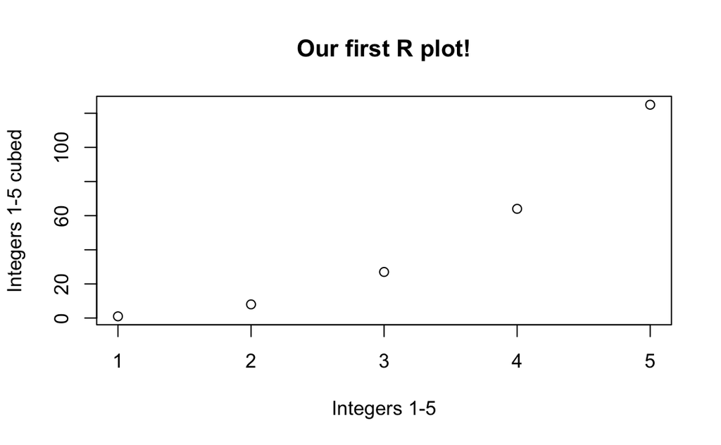

```r
x = c(1, 2, 3, 4, 5)
y = c(1, 8, 27, 64, 125)
plot(x, y, main="Our first R plot!",
     xlab = "Integers 1-5",
     ylab = "Integers 1-5 cubed")
```

We can always use `install.packages()` to install new packages.

We will use `install.packages("datasets")` to get datasets available.

We will then load that library as follows: `library(datasets)`.

We want to get `data(faithful)` so we can do the following plot:

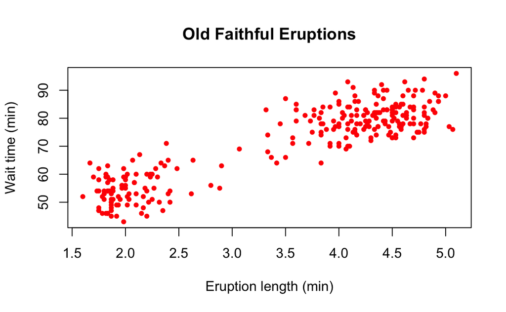

```r
library(datasets)
data("faithful")
plot(faithful, main="Old Faithful Eruptions",
     xlab = "Eruption length (min)",
     ylab = "Wait time (min)", pch=20, col="red")
```

Now just the data.

```r
library(datasets)
data("faithful")
faithful
```

|  | eruptions | waiting |
| --- | --- | --- |
| 1 | 3.600 | 79 |
| 2 | 1.800 | 54 |
| 3 | 3.333 | 74 |
| 4 | 2.283 | 62 |
| 5 | 4.533 | 85 |
| 6 | 2.883 | 55 |
| 7 | 4.700 | 88 |
| 8 | 3.600 | 85 |
| 9 | 1.950 | 51 |
| 10 | 4.350 | 85 |

[output cut: 262 more lines]

# Histogram

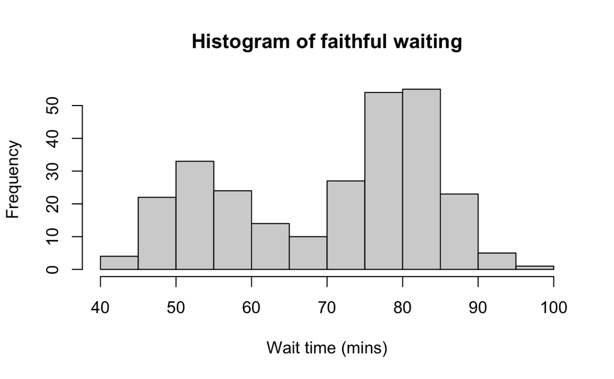

```r
hist(faithful$waiting, main="Histogram of faithful waiting",
     xlab = "Wait time (mins)",
     ylab = "Frequency")
```

Look to see where the breaks are in the data:

```r
# breaks in the dataset
hist(faithful$waiting, plot=FALSE)$breaks
```

```
 [1]  40  45  50  55  60  65  70  75  80  85  90  95 100
```

```r
hist(faithful$waiting, plot=FALSE)$counts
```

```
 [1]  4 22 33 24 14 10 27 54 55 23  5  1
```

Creating a histogram with bin size = 1. We would use the following code:

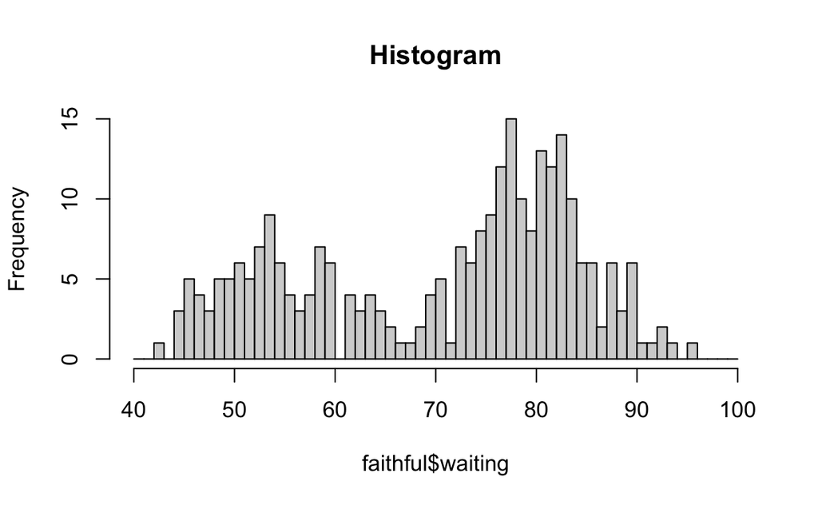

```r
hist(faithful$waiting,main="Histogram",
     breaks=seq(from=40,to=100,by=1))
```

```r
# Breaks
hist(faithful$waiting,
     breaks = seq(from=40,to=100,by=1), plot=FALSE)$breaks
```

```
 [1]  40  41  42  43  44  45  46  47  48  49  50  51  52  53  54  55  56  57
[19]  58  59  60  61  62  63  64  65  66  67  68  69  70  71  72  73  74  75
[37]  76  77  78  79  80  81  82  83  84  85  86  87  88  89  90  91  92  93
[55]  94  95  96  97  98  99 100
```

```r
# Counts
hist(faithful$waiting,
     breaks=seq(from=40,to=100,by=1), plot=FALSE)$counts
```

```
 [1]  0  0  1  0  3  5  4  3  5  5  6  5  7  9  6  4  3  4  7  6  0  4  3  4  3
[26]  2  1  1  2  4  5  1  7  6  8  9 12 15 10  8 13 12 14 10  6  6  2  6  3  6
[51]  1  1  2  1  0  1  0  0  0  0
```

Making a QQ Plot

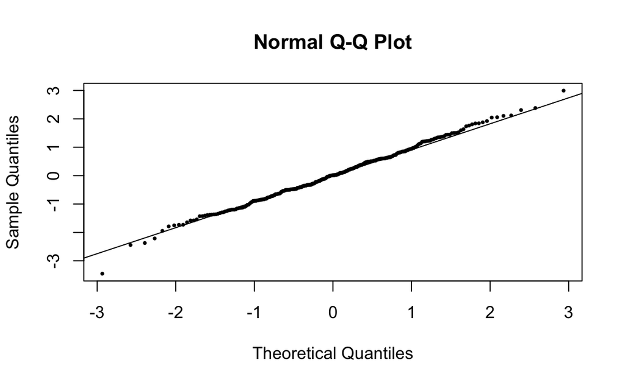

```r
x = rnorm(300)
qqnorm(x,pch=16,cex=.5)
qqline(x)
```

Let’s do a QQ plot for the Old Faithful Waiting data.

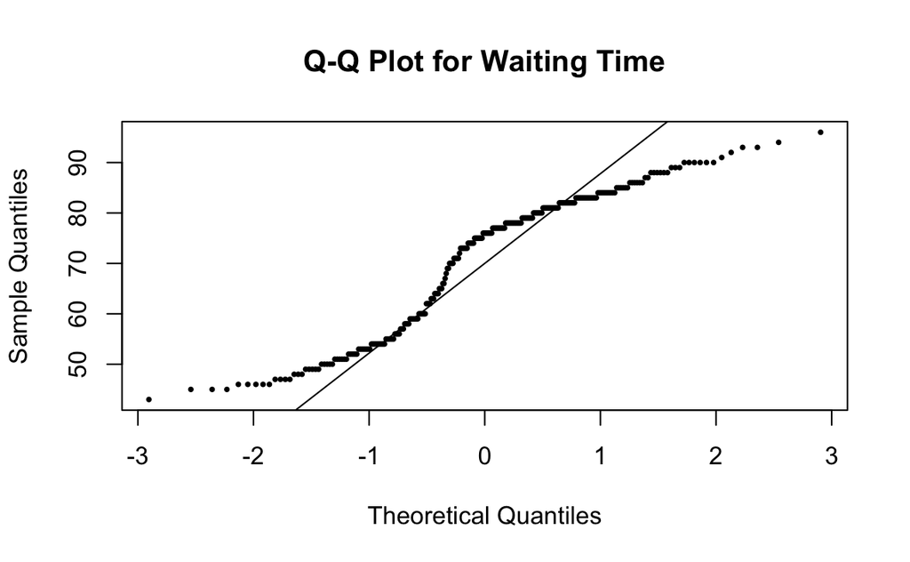

```r
qqnorm(faithful$waiting,pch=16,cex=.5,
       main = "Q-Q Plot for Waiting Time")

qqline(faithful$waiting)
```

What we take from this, relative to our simulated normal data in the prior QQ plot, is that the Old Faithful Wait Times are not normally distributed.

Looking a variation from the normal line in simulated data.

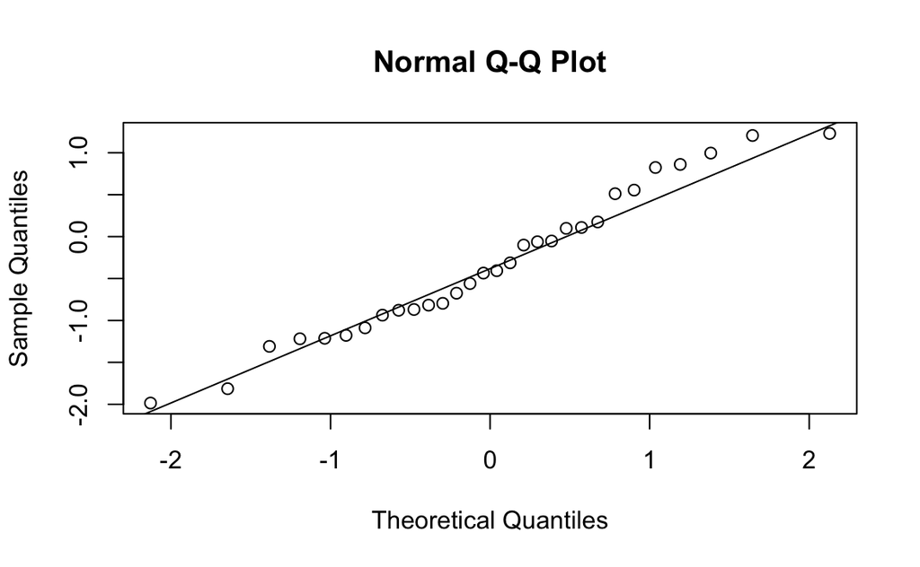

```r
x = rnorm(30); qqnorm(x); qqline(x)
```

Even this line has data that pulls away from the normal line.

How does sample size impact this? Let’s look at a larger sample.

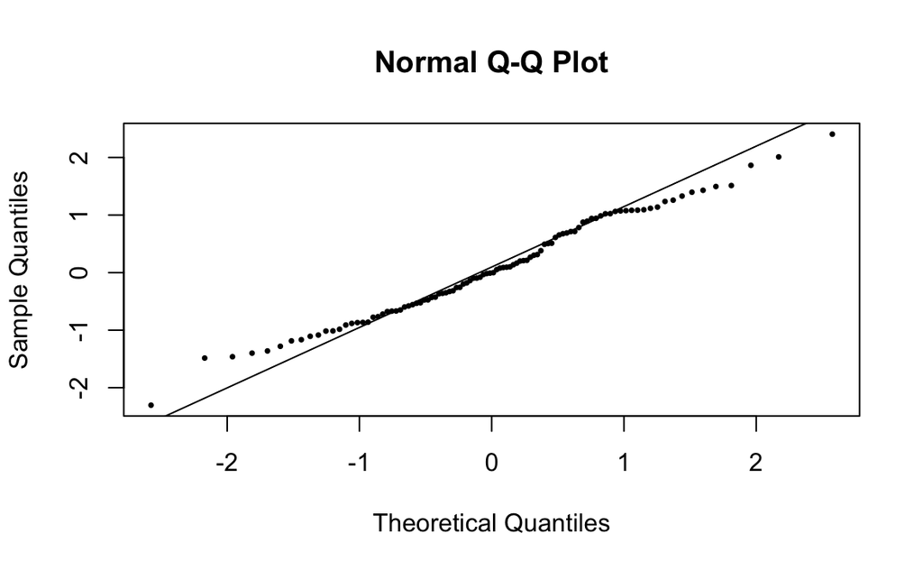

```r
x = rnorm(100); qqnorm(x,pch=16,cex=.5); qqline(x)
```

## Gotchas!

Don’t write over built-in functions like `mean`, `c`, or `t`.

You can guard against this by doing `?var_name`.

See below:

```r
?mean
```

When we run that code in the help window on the right, we see the definition of the variable. Similar to the others listed above.